# Limpieza y análisis de datos

Mauricio Mosquera Sánchez.

24-12-2020

# 1 Detalles de la actividad

## 1.1 Descripción

En esta práctica se elabora un caso práctico orientado a aprender a identificar los datos relevantes para un proyecto analítico y usar las herramientas de integración, limpieza, validación y análisis de las mismas.

- Ejemplo: https://github.com/Bengis/nba-gap-cleaning
- Ejemplo complejo (archivo adjunto).

## 1.2 Objetivos

Los objetivos concretos de esta práctica son:

- Aprender a aplicar los conocimientos adquiridos y su capacidad de resolución de problemas en entornos nuevos o poco conocidos dentro de contextos más amplios o multidisciplinares.
- Saber identificar los datos relevantes y los tratamientos necesarios (integración, limpieza y validación) para llevar a cabo un proyecto analítico.
- Aprender a analizar los datos adecuadamente para abordar la información contenida en los datos.
- Identificar la mejor representación de los resultados para aportar conclusiones sobre el problema planteado en el proceso analítico.
- Actuar con los principios éticos y legales relacionados con la manipulación de datos en función del ámbito de aplicación.
- Desarrollar las habilidades de aprendizaje que les permitan continuar estudiando de un modo que tendrá que ser en gran medida autodirigido o autónomo.
- Desarrollar la capacidad de búsqueda, gestión y uso de información y recursos en el ámbito de la ciencia de datos.

## 1.3 Competencias

En esta práctica se desarrollan las siguientes competencias del Máster de Data Science:

- Capacidad de analizar un problema en el nivel de abstracción adecuado a cada situación y aplicar las habilidades y conocimientos adquiridos para abordarlo y resolverlo.
- Capacidad para aplicar las técnicas específicas de tratamiento de datos (integración, transformación, limpieza y validación) para su posterior análisis.

# 2 Desarrollo

## 2.1 Descripción del dataset.

El conjunto de datos objeto de análisis esta compuesto por 12 columnas y 1599 filas. Estos datos están relacionados con la variante tinto del vino portugués “Vinho Verde” los cuales fueron obtenidos a partir del enlace en Kaggle: **https://www.kaggle.com/uciml/red-wine-quality-cortez-et-al-2009**. Las variables encontradas en los datos son las siguientes:

Variables de entrada (basadas en pruebas fisicoquímicas):

- **fixed acidity:** acidez fija (ácido tartárico - g/dm^3) se debe a los ácidos orgánicos involucrados con el vino.
- **volatile acidity:** acidez volátil (ácido acético - g/dm^3) se debe a la cantidad de ácido acético en el vino, que en niveles demasiado altos puede provocar un sabor desagradable a vinagre.
- **citric acid:** ácido cítrico (g/dm^3) es un corrector de la acidez en vinos y se encuentra en pequeñas cantidades, el ácido cítrico puede agregar “frescura” y sabor a los vinos.
- **residual sugar:** azúcar residual (g/dm^3) es la cantidad de azúcar que queda después de que se detiene la fermentación, es raro encontrar vinos con menos de 1 gramo/litro y vinos con más de 45 gramos/litro se consideran dulces.
- **chlorides:** cloruros (cloruro de sodio - g/dm^3) es la cantidad de sal en el vino.
- **free sulfur dioxide:** dióxido de azufre libre (mg/dm^3) es la forma libre de SO2 existente en equilibrio entre el SO2 molecular (como gas disuelto) y el ion bisulfito; previene el crecimiento microbiano y la oxidación del vino.
- **total sulfur dioxide:** dióxido de azufre total (mg/dm^3) es la cantidad de formas libres y unidas de SO2; en bajas concentraciones, el SO2 es mayormente indetectable en el vino, pero en concentraciones de SO2 libre superiores a 50 ppm, el SO2 se hace evidente en la nariz y el sabor del vino.
- **density:** Densidad (g/cm^3) la densidad del vino es cercana a la del agua dependiendo del porcentaje de alcohol y contenido de azúcar.
- **pH:** pH describe qué tan ácido o básico es un vino en una escala de 0 (muy ácido) a 14 (muy básico); la mayoría de los vinos están entre 3-4 en la escala de pH.
- **sulphates:** sulfatos (sulfato de potasio - g/dm3) es un aditivo del vino que puede contribuir a los niveles de dióxido de azufre (S02), actúa como antimicrobiano y antioxidante.
- **alcohol:** alcohol (% por volumen) porcentaje de contenido de alcohol en el vino.

Variable de salida (basada en datos sensoriales):

- **quality:** calidad (puntuación entre 0 y 10)

**¿Por qué es importante y qué pregunta/problema pretende responder?**

Los parámetros para medir la calidad del vino son varios. Algunos de ellos están relacionados al gusto, otros al aspecto visual y estético, otros a las uvas con las que está hecho. Conocer cada uno de esos aspectos es esencial para hacer una buena elección y servir en la copa un maravilloso vino. Este análisis está centrado principalmente en la calidad del vino en su variedad tinto (rojo). La “calidad” del vino, la cual es típicamente medida, tiene componentes subjetivos, los cuales controlan en mayor o menor medida el sabor. Sin embargo, la principal pregunta planteada es:

¿Es posible ver alguna relación entre la calidad del vino y los índices tomados mediante pruebas fisioquimicas?

## 2.2 Integración y selección de los datos de interés a analizar.

```r
# Cargar los datos
dataset <- read_csv("C:/Users/Acer/Dropbox/Data science/Tipologia y ciclo de vida de los datos/Bloque 3 - Limpieza y análisis de los datos/Limpieza y análisis de datos/winequality-red.csv")
```

El conjunto de datos tiene 11 variables que pueden influir en la calidad del vino por lo que para su análisis conservaremos todas las variables para su análisis:

## 2.3 Limpieza de los datos.

```r
# Identificar la clase de las variables
sapply(dataset, function(x) class(x))
```

```
##        fixed acidity     volatile acidity          citric acid
##            "numeric"            "numeric"            "numeric"
##       residual sugar            chlorides  free sulfur dioxide
##            "numeric"            "numeric"            "numeric"
## total sulfur dioxide              density                   pH
##            "numeric"            "numeric"            "numeric"
##            sulphates              alcohol              quality
##            "numeric"            "numeric"            "numeric"
```

### 2.3.1 ¿Los datos contienen ceros o elementos vacíos? ¿Cómo gestionarías cada uno de estos casos?

```r
# Conocer el número de NAs por columna
colSums(is.na(dataset))
```

```
##        fixed acidity     volatile acidity          citric acid
##                    0                    0                    0
##       residual sugar            chlorides  free sulfur dioxide
##                    0                    0                    0
## total sulfur dioxide              density                   pH
##                    0                    0                    0
##            sulphates              alcohol              quality
##                    0                    0                    0
```

```r
# Conocer los valores 0
sapply(dataset, function(x) sum(x==0))
```

```
##        fixed acidity     volatile acidity          citric acid
##                    0                    0                  132
##       residual sugar            chlorides  free sulfur dioxide
##                    0                    0                    0
## total sulfur dioxide              density                   pH
##                    0                    0                    0
##            sulphates              alcohol              quality
##                    0                    0                    0
```

En este conjunto de datos no existe ninguna variable que contenga elementos vacíos, la variable ácido cítrico tiene 132 elementos con valor 0. En nuestro caso se los conserva ya que es una variables que se mide en cantidades muy pequeñas inclusive puede no haber cantidad de ácido cítrico en el vino

### 2.3.2 Identificación y tratamiento de valores extremos.

```r
# Identificar los outliers
sapply(dataset[-12], function(x) boxplot.stats(x)$out)
```

```
## $`fixed acidity`
##  [1] 12.8 12.8 15.0 15.0 12.5 13.3 13.4 12.4 12.5 13.8 13.5 12.6 12.5 12.8 12.8
## [16] 14.0 13.7 13.7 12.7 12.5 12.8 12.6 15.6 12.5 13.0 12.5 13.3 12.4 12.5 12.9
## [31] 14.3 12.4 15.5 15.5 15.6 13.0 12.7 13.0 12.7 12.4 12.7 13.2 13.2 13.2 15.9
## [46] 13.3 12.9 12.6 12.6
##
## $`volatile acidity`
##  [1] 1.130 1.020 1.070 1.330 1.330 1.040 1.090 1.040 1.240 1.185 1.020 1.035
## [13] 1.025 1.115 1.020 1.020 1.580 1.180 1.040
##
## $`citric acid`
## [1] 1
##
## $`residual sugar`
##   [1]  6.10  6.10  3.80  3.90  4.40 10.70  5.50  5.90  5.90  3.80  5.10  4.65
```

[output cut: 55 more lines]

```r
# Imputar los outliers
impute_outliers <- function(x){
  quantiles <- quantile(x, c(0.05, 0.95))
  x[x<quantiles[1]] <- mean(x)
  x[x>quantiles[2]] <- median(x)
  x
}
dataset$`fixed acidity`<-round(impute_outliers(dataset$`fixed acidity`),1)
dataset$`volatile acidity`<-round(impute_outliers(dataset$`volatile acidity`),3)
dataset$`citric acid`<-round(impute_outliers(dataset$`citric acid`),2)
dataset$`residual sugar`<-round(impute_outliers(dataset$`residual sugar`),2)
dataset$chlorides<-round(impute_outliers(dataset$chlorides),3)
dataset$`free sulfur dioxide`<-round(impute_outliers(dataset$`free sulfur dioxide`),0)
dataset$`total sulfur dioxide`<-round(impute_outliers(dataset$`total sulfur dioxide`),0)
dataset$density<-round(impute_outliers(dataset$density),4)
dataset$pH<-round(impute_outliers(dataset$pH),2)
dataset$sulphates<-round(impute_outliers(dataset$sulphates),2)
dataset$alcohol<-round(impute_outliers(dataset$alcohol),1)
```

## 2.4 Análisis de los datos.

### 2.4.1 Selección de los grupos de datos que se quieren analizar/comparar.

```r
# Selección de los grupos
select(dataset, `fixed acidity`, quality)
```

```
## # A tibble: 1,599 x 2
##    `fixed acidity` quality
##              <dbl>   <dbl>
##  1             7.4       5
##  2             7.8       5
##  3             7.8       5
##  4            11.2       6
##  5             7.4       5
##  6             7.4       5
##  7             7.9       5
##  8             7.3       7
##  9             7.8       7
## 10             7.5       5
## # ... with 1,589 more rows
```

```r
select(dataset, `volatile acidity`, quality)
```

```
## # A tibble: 1,599 x 2
##    `volatile acidity` quality
##                 <dbl>   <dbl>
##  1              0.7         5
##  2              0.528       5
##  3              0.76        5
##  4              0.28        6
##  5              0.7         5
##  6              0.66        5
##  7              0.6         5
##  8              0.65        7
##  9              0.580       7
## 10              0.5         5
## # ... with 1,589 more rows
```

```r
select(dataset, `citric acid`, quality)
```

```
## # A tibble: 1,599 x 2
##    `citric acid` quality
##            <dbl>   <dbl>
##  1          0          5
##  2          0          5
##  3          0.04       5
##  4          0.56       6
##  5          0          5
##  6          0          5
##  7          0.06       5
##  8          0          7
##  9          0.02       7
## 10          0.36       5
## # ... with 1,589 more rows
```

```r
select(dataset, `residual sugar`, quality)
```

```
## # A tibble: 1,599 x 2
##    `residual sugar` quality
##               <dbl>   <dbl>
##  1             1.9        5
##  2             2.6        5
##  3             2.3        5
##  4             1.9        6
##  5             1.9        5
##  6             1.8        5
##  7             1.6        5
##  8             2.54       7
##  9             2          7
## 10             2.2        5
## # ... with 1,589 more rows
```

```r
select(dataset, chlorides, quality)
```

```
## # A tibble: 1,599 x 2
##    chlorides quality
##        <dbl>   <dbl>
##  1     0.076       5
##  2     0.098       5
##  3     0.092       5
##  4     0.075       6
##  5     0.076       5
##  6     0.075       5
##  7     0.069       5
##  8     0.065       7
##  9     0.073       7
## 10     0.071       5
## # ... with 1,589 more rows
```

```r
select(dataset, `free sulfur dioxide`, quality)
```

```
## # A tibble: 1,599 x 2
##    `free sulfur dioxide` quality
##                    <dbl>   <dbl>
##  1                    11       5
##  2                    25       5
##  3                    15       5
##  4                    17       6
##  5                    11       5
##  6                    13       5
##  7                    15       5
##  8                    15       7
##  9                     9       7
## 10                    17       5
## # ... with 1,589 more rows
```

```r
select(dataset, `total sulfur dioxide`, quality)
```

```
## # A tibble: 1,599 x 2
##    `total sulfur dioxide` quality
##                     <dbl>   <dbl>
##  1                     34       5
##  2                     67       5
##  3                     54       5
##  4                     60       6
##  5                     34       5
##  6                     40       5
##  7                     59       5
##  8                     21       7
##  9                     18       7
## 10                    102       5
## # ... with 1,589 more rows
```

```r
select(dataset, density, quality)
```

```
## # A tibble: 1,599 x 2
##    density quality
##      <dbl>   <dbl>
##  1   0.998       5
##  2   0.997       5
##  3   0.997       5
##  4   0.998       6
##  5   0.998       5
##  6   0.998       5
##  7   0.996       5
##  8   0.995       7
##  9   0.997       7
## 10   0.998       5
## # ... with 1,589 more rows
```

```r
select(dataset, pH, quality)
```

```
## # A tibble: 1,599 x 2
##       pH quality
##    <dbl>   <dbl>
##  1  3.51       5
##  2  3.2        5
##  3  3.26       5
##  4  3.16       6
##  5  3.51       5
##  6  3.51       5
##  7  3.3        5
##  8  3.39       7
##  9  3.36       7
## 10  3.35       5
## # ... with 1,589 more rows
```

```r
select(dataset, sulphates, quality)
```

```
## # A tibble: 1,599 x 2
##    sulphates quality
##        <dbl>   <dbl>
##  1     0.56        5
##  2     0.68        5
##  3     0.65        5
##  4     0.580       6
##  5     0.56        5
##  6     0.56        5
##  7     0.66        5
##  8     0.47        7
##  9     0.570       7
## 10     0.8         5
## # ... with 1,589 more rows
```

```r
select(dataset, alcohol, quality)
```

```
## # A tibble: 1,599 x 2
##    alcohol quality
##      <dbl>   <dbl>
##  1     9.4       5
##  2     9.8       5
##  3     9.8       5
##  4     9.8       6
##  5     9.4       5
##  6     9.4       5
##  7     9.4       5
##  8    10         7
##  9     9.5       7
## 10    10.5       5
## # ... with 1,589 more rows
```

### 2.4.2 Comprobación de la normalidad y homogeneidad de la varianza.

```r
# Comprobar la normalidad
sapply(dataset, function(x) lillie.test(x))
```

```
##           fixed acidity
## statistic 0.1272158
## p.value   7.7408e-71
## method    "Lilliefors (Kolmogorov-Smirnov) normality test"
## data.name "x"
##           volatile acidity
## statistic 0.05662714
## p.value   5.219059e-13
## method    "Lilliefors (Kolmogorov-Smirnov) normality test"
## data.name "x"
##           citric acid
## statistic 0.08437164
## p.value   4.140156e-30
## method    "Lilliefors (Kolmogorov-Smirnov) normality test"
## data.name "x"
##           residual sugar
## statistic 0.1535828
## p.value   1.522794e-104
## method    "Lilliefors (Kolmogorov-Smirnov) normality test"
## data.name "x"
##           chlorides
## statistic 0.09090866
## p.value   3.362777e-35
## method    "Lilliefors (Kolmogorov-Smirnov) normality test"
## data.name "x"
##           free sulfur dioxide
## statistic 0.110008
## p.value   2.16627e-52
## method    "Lilliefors (Kolmogorov-Smirnov) normality test"
## data.name "x"
##           total sulfur dioxide
## statistic 0.113633
## p.value   4.816816e-56
## method    "Lilliefors (Kolmogorov-Smirnov) normality test"
## data.name "x"
##           density
## statistic 0.06875044
## p.value   1.386909e-19
## method    "Lilliefors (Kolmogorov-Smirnov) normality test"
## data.name "x"
##           pH
## statistic 0.05882467
## p.value   4.255582e-14
## method    "Lilliefors (Kolmogorov-Smirnov) normality test"
## data.name "x"
##           sulphates
## statistic 0.1105839
## p.value   5.802972e-53
## method    "Lilliefors (Kolmogorov-Smirnov) normality test"
## data.name "x"
##           alcohol
## statistic 0.09725293
## p.value   1.583067e-40
## method    "Lilliefors (Kolmogorov-Smirnov) normality test"
## data.name "x"
##           quality
## statistic 0.2498185
## p.value   1.951455e-283
## method    "Lilliefors (Kolmogorov-Smirnov) normality test"
## data.name "x"
```

Existe evidencia estadística para rechazar la H0. Es decir, podemos afirmar que las variables del dataset no tienen una distribución normal.

```r
# homogeneidad de la varianza
sapply(dataset, function(x) var(x))
```

```
##        fixed acidity     volatile acidity          citric acid
##         1.634954e+00         1.773274e-02         2.931972e-02
##       residual sugar            chlorides  free sulfur dioxide
##         3.430968e-01         1.893487e-04         6.225541e+01
## total sulfur dioxide              density                   pH
##         5.825810e+02         1.808479e-06         1.291389e-02
##            sulphates              alcohol              quality
##         1.086224e-02         7.343661e-01         6.521684e-01
```

Las varianzas de las variables del dataset no son iguales

#### 2.4.2.1 Acidez fija

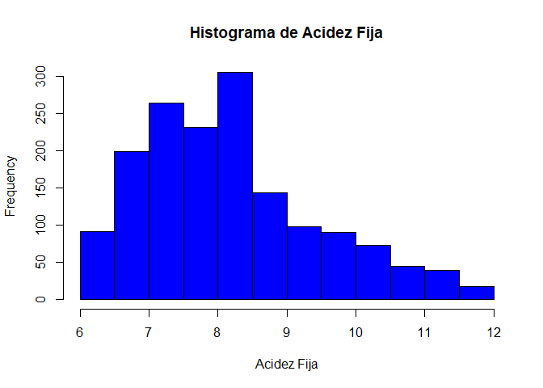

```r
hist(dataset$`fixed acidity`,main = 'Histograma de Acidez Fija',xlab = 'Acidez Fija', col="blue")
```

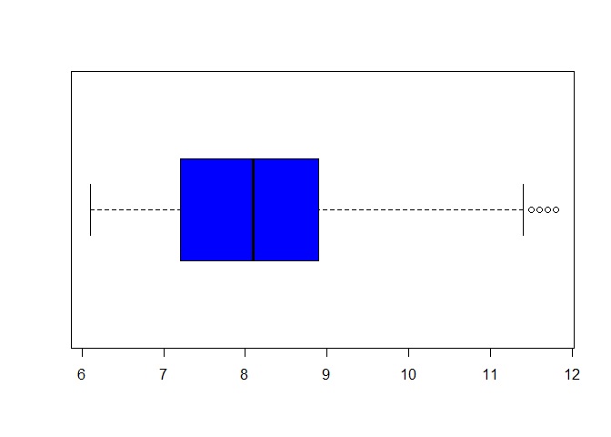

```r
boxplot(dataset$`fixed acidity`,horizontal = TRUE, col="blue")
```

```r
summary(dataset$`fixed acidity`)
```

```
##    Min. 1st Qu.  Median    Mean 3rd Qu.    Max.
##   6.100   7.200   8.100   8.212   8.900  11.800
```

```r
sd(dataset$`fixed acidity`)
```

```
## [1] 1.278653
```

```r
kurtosis(dataset$`fixed acidity`)
```

```
## [1] 2.961393
```

```r
skewness(dataset$`fixed acidity`)
```

```
## [1] 0.7297093
```

En base al diagrama de cajas se estableció un máximo y mínimo de (11.80) y (6.10) respectivamente, el histograma de frecuencia ubicaba la mayor cantidad de datos en el intervalo [8.00, 8.50] en el cual se encuentra la media (8.21) y la mediana (8.10). Esta variable presenta una desviacion estandar de (1.28) siendo aun valores cercanos; tiene una curtosis de (2.96) y representa una distribución Platicúrtica; además tiene un sesgo de (0.73) que representa tener una asimetría positiva.

#### 2.4.2.2 Acidez volátil

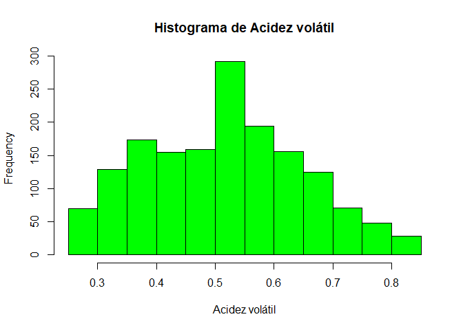

```r
hist(dataset$`volatile acidity`,main = 'Histograma de Acidez volátil',xlab = 'Acidez volátil', col="green")
```

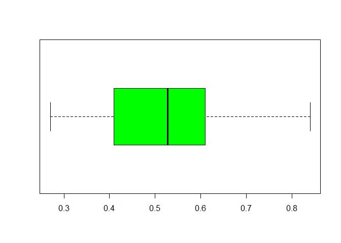

```r
boxplot(dataset$`volatile acidity`,horizontal = TRUE, col="green")
```

```r
summary(dataset$`volatile acidity`)
```

```
##    Min. 1st Qu.  Median    Mean 3rd Qu.    Max.
##  0.2700  0.4100  0.5280  0.5209  0.6100  0.8400
```

```r
sd(dataset$`volatile acidity`)
```

```
## [1] 0.1331643
```

```r
kurtosis(dataset$`volatile acidity`)
```

```
## [1] 2.353495
```

```r
skewness(dataset$`volatile acidity`)
```

```
## [1] 0.1337394
```

En base al diagrama de cajas se estableció un máximo y mínimo de (0.84) y (0.27) respectivamente, el histograma de frecuencia ubicaba la mayor cantidad de datos en el intervalo [0.50, 0.55] en el cual se encuentra la media (0.52) y la mediana (0.53). Esta variable presenta una desviacion estandar de (0.13) siendo aun valores cercanos; tiene una curtosis de (2.35) y representa una distribución Platicúrtica; además tiene un sesgo de (0.13) que representa tener una simetría.

#### 2.4.2.3 Ácido cítrico

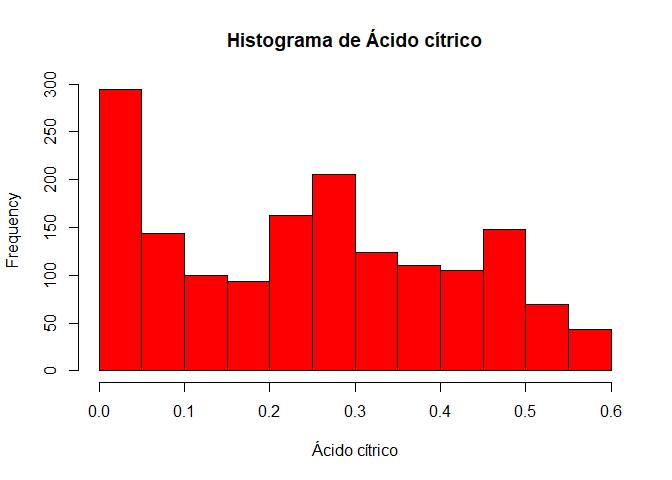

```r
hist(dataset$`citric acid`,main = 'Histograma de Ácido cítrico',xlab = 'Ácido cítrico', col="red")
```

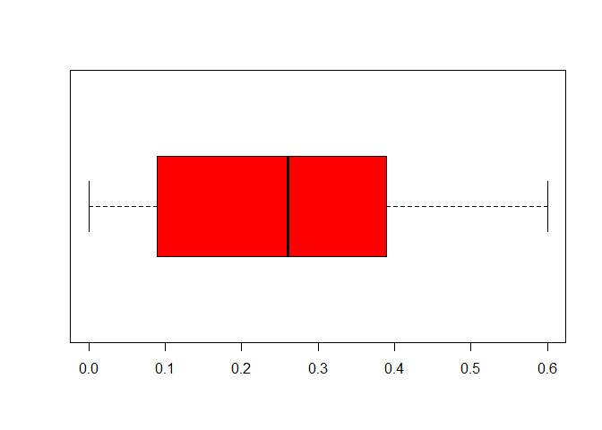

```r
boxplot(dataset$`citric acid`,horizontal = TRUE, col="red")
```

```r
summary(dataset$`citric acid`)
```

```
##    Min. 1st Qu.  Median    Mean 3rd Qu.    Max.
##  0.0000  0.0900  0.2600  0.2506  0.3900  0.6000
```

```r
sd(dataset$`citric acid`)
```

```
## [1] 0.17123
```

```r
kurtosis(dataset$`citric acid`)
```

```
## [1] 1.90202
```

```r
skewness(dataset$`citric acid`)
```

```
## [1] 0.1323302
```

#### 2.4.2.4 Azúcar residual

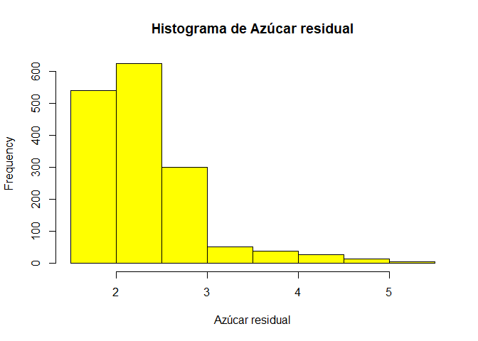

```r
hist(dataset$`residual sugar` ,main = 'Histograma de Azúcar residual',xlab = 'Azúcar residual',col="yellow")
```

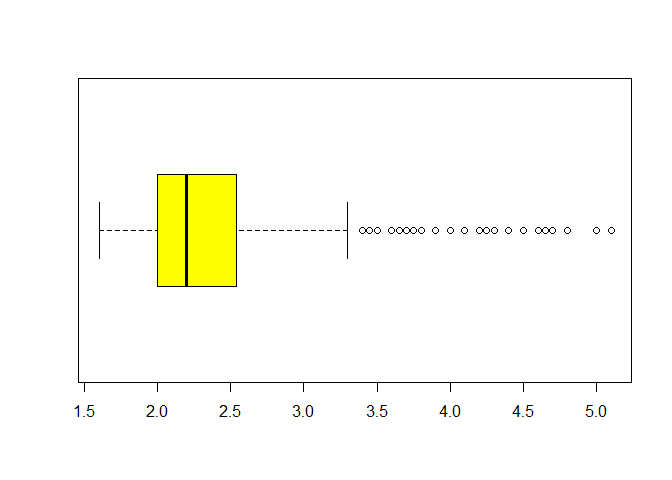

```r
boxplot(dataset$`residual sugar`, horizontal = TRUE, col="yellow")
```

```r
summary(dataset$`residual sugar`)
```

```
##    Min. 1st Qu.  Median    Mean 3rd Qu.    Max.
##   1.600   2.000   2.200   2.336   2.540   5.100
```

```r
sd(dataset$`residual sugar`)
```

```
## [1] 0.5857446
```

```r
kurtosis(dataset$`residual sugar`)
```

```
## [1] 7.507205
```

```r
skewness(dataset$`residual sugar`)
```

```
## [1] 1.870874
```

En base al diagrama de cajas se estableció un máximo y mínimo de (5.10) y (1.60) respectivamente, el histograma de frecuencia ubicaba la mayor cantidad de datos en el intervalo [2.00, 2.50] en el cual se encuentra la media (2.34) y la mediana (2.20). Esta variable presenta una desviacion estandar de (0.59) siendo estos valores muy cercanos; tiene una curtosis de (7.51) y representa una distribución leptocúrtica; además tiene un sesgo de (1.87) que representa tener una asimetría ya que los datos estan muy sesgados.

#### 2.4.2.5 cloruros

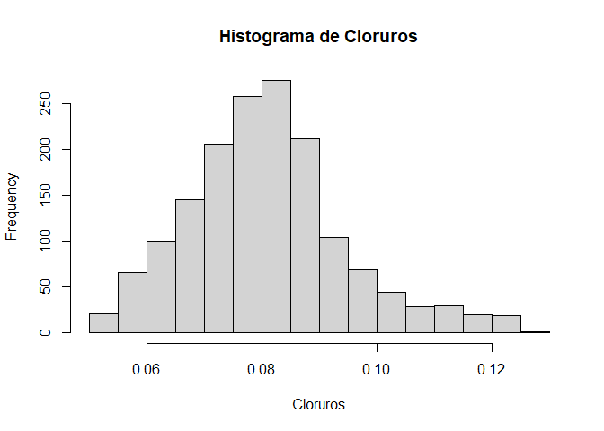

```r
hist(dataset$chlorides ,main = 'Histograma de Cloruros',xlab = 'Cloruros')
```

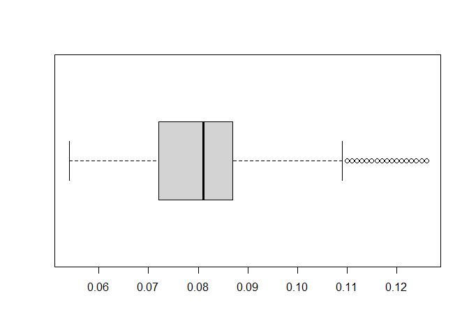

```r
boxplot(dataset$chlorides, horizontal = TRUE)
```

```r
summary(dataset$chlorides)
```

```
##    Min. 1st Qu.  Median    Mean 3rd Qu.    Max.
## 0.05400 0.07200 0.08100 0.08122 0.08700 0.12600
```

```r
sd(dataset$chlorides)
```

```
## [1] 0.0137604
```

```r
kurtosis(dataset$chlorides)
```

```
## [1] 3.631319
```

```r
skewness(dataset$chlorides)
```

```
## [1] 0.6520554
```

En base al diagrama de cajas se estableció un máximo y mínimo de (0.13) y (0.05) respectivamente, el histograma de frecuencia ubicaba la mayor cantidad de datos en el intervalo [0.08, 0.09] en el cual se encuentra la media (0.08) y la mediana (0.08). Esta variable presenta una desviacion estandar de (0.014) siendo estos valores muy cercanos; tiene una curtosis de (3.63) y representa una distribución leptocúrtica; además tiene un sesgo de (0.65) que representa tener una asimetría positiva.

#### 2.4.2.6 dióxido de azufre libre

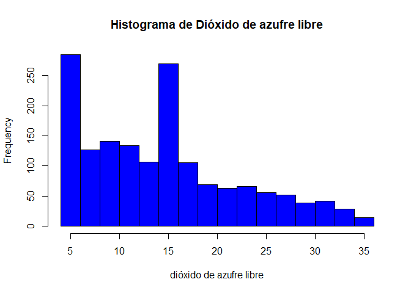

```r
hist(dataset$`free sulfur dioxide` ,main = 'Histograma de Dióxido de azufre libre',xlab = 'dióxido de azufre libre',col="blue")
```

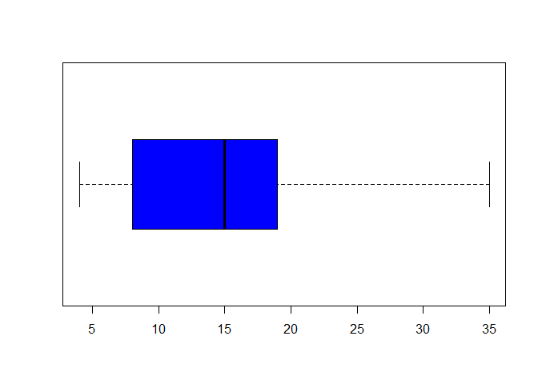

```r
boxplot(dataset$`free sulfur dioxide`, horizontal = TRUE,col="blue")
```

```r
summary(dataset$`free sulfur dioxide`)
```

```
##    Min. 1st Qu.  Median    Mean 3rd Qu.    Max.
##    4.00    8.00   15.00   14.93   19.00   35.00
```

```r
sd(dataset$`free sulfur dioxide`)
```

```
## [1] 7.89021
```

```r
kurtosis(dataset$`free sulfur dioxide`)
```

```
## [1] 2.663356
```

```r
skewness(dataset$`free sulfur dioxide`)
```

```
## [1] 0.6687822
```

#### 2.4.2.7 dióxido de azufre total

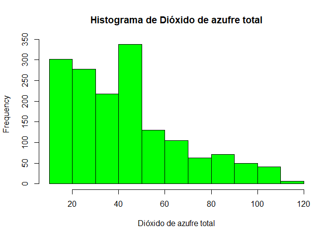

```r
hist(dataset$`total sulfur dioxide` ,main = 'Histograma de Dióxido de azufre total',xlab = 'Dióxido de azufre total',col="green")
```

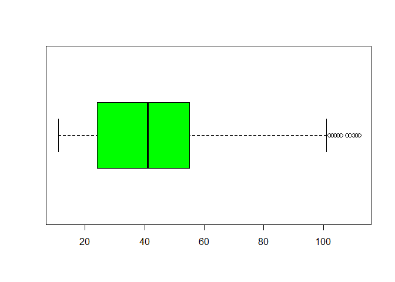

```r
boxplot(dataset$`total sulfur dioxide`, horizontal = TRUE, col="green")
```

```r
summary(dataset$`total sulfur dioxide`)
```

```
##    Min. 1st Qu.  Median    Mean 3rd Qu.    Max.
##   11.00   24.00   41.00   43.16   55.00  112.00
```

```r
sd(dataset$`total sulfur dioxide`)
```

```
## [1] 24.13671
```

```r
kurtosis(dataset$`total sulfur dioxide`)
```

```
## [1] 3.116269
```

```r
skewness(dataset$`total sulfur dioxide`)
```

```
## [1] 0.8833999
```

En base al diagrama de cajas se estableció un máximo y mínimo de (112.00) y (11.00) respectivamente, el histograma de frecuencia ubicaba la mayor cantidad de datos en el intervalo [40.00, 50.00] en el cual se encuentra la media (43.16) y la mediana (41.00). Esta variable presenta una desviacion estandar de (24.14) siendo estos valores muy alejados; tiene una curtosis de (3.11) y representa una distribución leptocúrtica; además tiene un sesgo de (0.88) que representa tener una asimetría positiva.

#### 2.4.2.8 pH

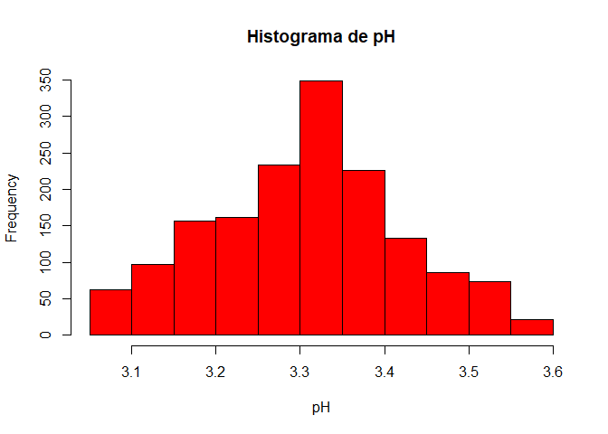

```r
hist(dataset$pH ,main = 'Histograma de pH',xlab = 'pH',col="red")
```

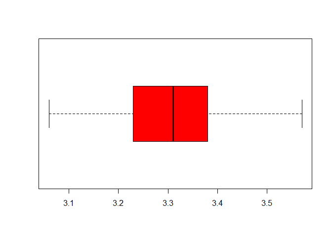

```r
boxplot(dataset$pH, horizontal = TRUE, col="red")
```

```r
summary(dataset$pH)
```

```
##    Min. 1st Qu.  Median    Mean 3rd Qu.    Max.
##    3.06    3.23    3.31    3.31    3.38    3.57
```

```r
sd(dataset$pH)
```

```
## [1] 0.1136393
```

```r
kurtosis(dataset$pH)
```

```
## [1] 2.563397
```

```r
skewness(dataset$pH)
```

```
## [1] 0.05598991
```

En base al diagrama de cajas se estableció un máximo y mínimo de (3.57) y (3.06) respectivamente, el histograma de frecuencia ubicaba la mayor cantidad de datos en el intervalo [3.30, 3.35] en el cual se encuentra la media (3.31) y la mediana (3.31). Esta variable presenta una desviacion estandar de (0.11) siendo estos valores muy cercanos; tiene una curtosis de (2.56) y representa una distribución Platicúrtica; además tiene un sesgo de (0.06) que representa tener bastante simetría.

#### 2.4.2.9 sulfatos

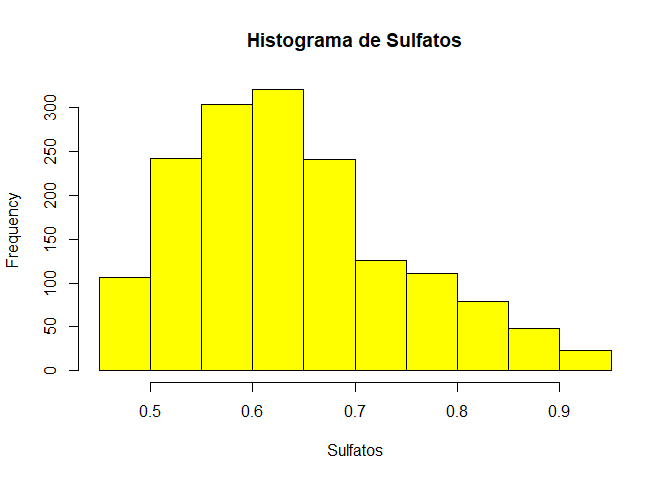

```r
hist(dataset$sulphates ,main = 'Histograma de Sulfatos',xlab = 'Sulfatos',col="yellow")
```

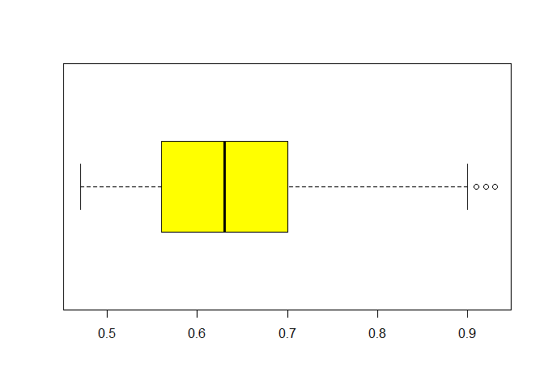

```r
boxplot(dataset$sulphates, horizontal = TRUE,col="yellow")
```

```r
summary(dataset$sulphates)
```

```
##    Min. 1st Qu.  Median    Mean 3rd Qu.    Max.
##  0.4700  0.5600  0.6300  0.6422  0.7000  0.9300
```

```r
sd(dataset$sulphates)
```

```
## [1] 0.1042221
```

```r
kurtosis(dataset$sulphates)
```

```
## [1] 2.885802
```

```r
skewness(dataset$sulphates)
```

```
## [1] 0.6708439
```

En base al diagrama de cajas se estableció un máximo y mínimo de (0.93) y (0.47) respectivamente, el histograma de frecuencia ubicaba la mayor cantidad de datos en el intervalo [0.60, 0.65] en el cual se encuentra la media (0.64) y la mediana (0.63). Esta variable presenta una desviacion estandar de (0.10) siendo estos valores muy cercanos; tiene una curtosis de (2.89) y representa una distribución Platicúrtica; además tiene un sesgo de (0.67) que representa tener una asimetría positiva.

#### 2.4.2.10 alcohol

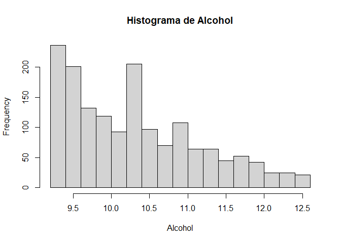

```r
hist(dataset$alcohol ,main = 'Histograma de Alcohol',xlab = 'Alcohol')
```

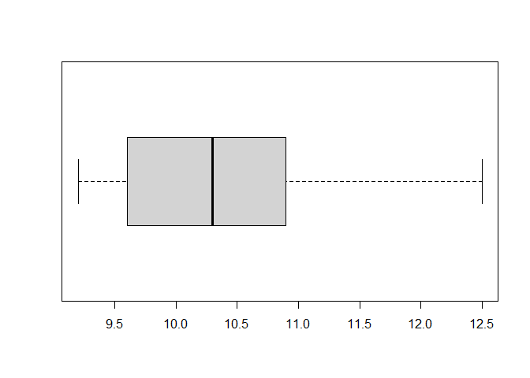

```r
boxplot(dataset$alcohol, horizontal = TRUE)
```

```r
summary(dataset$alcohol)
```

```
##    Min. 1st Qu.  Median    Mean 3rd Qu.    Max.
##    9.20    9.60   10.30   10.36   10.90   12.50
```

```r
sd(dataset$alcohol)
```

```
## [1] 0.8569516
```

```r
kurtosis(dataset$alcohol)
```

```
## [1] 2.530014
```

```r
skewness(dataset$alcohol)
```

```
## [1] 0.6383042
```

#### 2.4.2.11 calidad

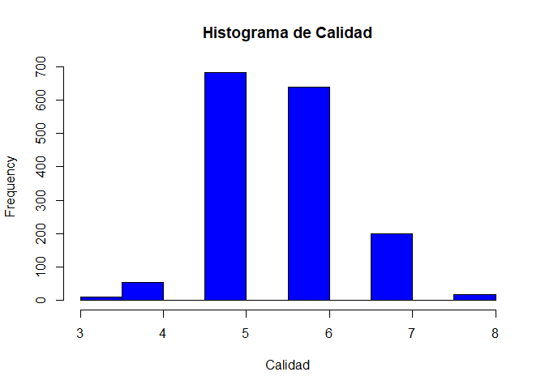

```r
hist(dataset$quality ,main = 'Histograma de Calidad',xlab = 'Calidad',col="blue")
```

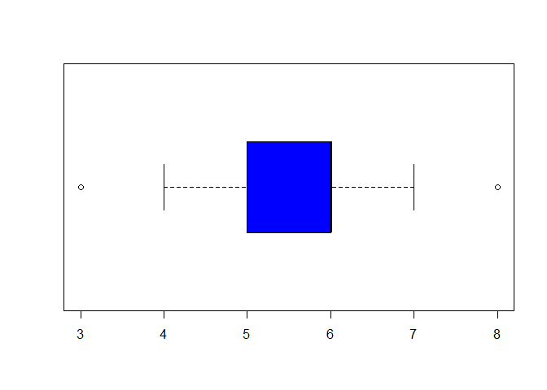

```r
boxplot(dataset$quality, horizontal = TRUE, col="blue")
```

```r
summary(dataset$quality)
```

```
##    Min. 1st Qu.  Median    Mean 3rd Qu.    Max.
##   3.000   5.000   6.000   5.636   6.000   8.000
```

```r
sd(dataset$quality)
```

```
## [1] 0.8075694
```

```r
kurtosis(dataset$quality)
```

```
## [1] 3.292031
```

```r
skewness(dataset$quality)
```

```
## [1] 0.2175972
```

En base al diagrama de cajas se estableció un máximo y mínimo de (8.0) y (3.0) respectivamente, el histograma de frecuencia ubicaba la mayor cantidad de datos en el intervalo [5.0, 6.0] en el cual se encuentra la media (5.6) y la mediana (6.0). Esta variable presenta una desviacion estandar de (0.81) siendo estos valores cercanos; tiene una curtosis de (3.29) y representa una distribución leptocúrtica; además tiene un sesgo de (0.22) que representa tener una simetría.

### 2.4.3 Aplicación de pruebas estadísticas para comparar los grupos de datos.

En función de los datos y el objetivo del estudio, aplicar pruebas de contraste de hipótesis, correlaciones, regresiones, etc. Aplicar al menos tres métodos de análisis diferentes.

#### 2.4.3.1 Correlaciones

```r
# Coeficiente de correlación parcial
cor.test(dataset$`fixed acidity`, dataset$quality, method = "pearson")
```

```
##
##  Pearson's product-moment correlation
##
## data:  dataset$`fixed acidity` and dataset$quality
## t = 5.8232, df = 1597, p-value = 6.967e-09
## alternative hypothesis: true correlation is not equal to 0
## 95 percent confidence interval:
##  0.09585011 0.19185871
## sample estimates:
##       cor
## 0.1441937
```

```r
cor.test(dataset$`volatile acidity`, dataset$quality, method = "pearson")
```

```
##
##  Pearson's product-moment correlation
##
## data:  dataset$`volatile acidity` and dataset$quality
## t = -12.867, df = 1597, p-value < 2.2e-16
## alternative hypothesis: true correlation is not equal to 0
## 95 percent confidence interval:
##  -0.3502360 -0.2613825
## sample estimates:
##        cor
## -0.3064767
```

```r
cor.test(dataset$`citric acid`, dataset$quality, method = "pearson")
```

```
##
##  Pearson's product-moment correlation
##
## data:  dataset$`citric acid` and dataset$quality
## t = 8.4268, df = 1597, p-value < 2.2e-16
## alternative hypothesis: true correlation is not equal to 0
## 95 percent confidence interval:
##  0.1589161 0.2527941
## sample estimates:
##       cor
## 0.2063299
```

```r
cor.test(dataset$`residual sugar`, dataset$quality, method = "pearson")
```

```
##
##  Pearson's product-moment correlation
##
## data:  dataset$`residual sugar` and dataset$quality
## t = 0.15796, df = 1597, p-value = 0.8745
## alternative hypothesis: true correlation is not equal to 0
## 95 percent confidence interval:
##  -0.04507711  0.05296364
## sample estimates:
##         cor
## 0.003952764
```

```r
cor.test(dataset$chlorides, dataset$quality, method = "pearson")
```

```
##
##  Pearson's product-moment correlation
##
## data:  dataset$chlorides and dataset$quality
## t = -4.8767, df = 1597, p-value = 1.186e-06
## alternative hypothesis: true correlation is not equal to 0
## 95 percent confidence interval:
##  -0.16915032 -0.07254324
## sample estimates:
##        cor
## -0.1211336
```

```r
cor.test(dataset$`free sulfur dioxide`, dataset$quality, method = "pearson")
```

```
##
##  Pearson's product-moment correlation
##
## data:  dataset$`free sulfur dioxide` and dataset$quality
## t = -2.1275, df = 1597, p-value = 0.03353
## alternative hypothesis: true correlation is not equal to 0
## 95 percent confidence interval:
##  -0.101917804 -0.004151951
## sample estimates:
##         cor
## -0.05316227
```

```r
cor.test(dataset$`total sulfur dioxide`, dataset$quality, method = "pearson")
```

```
##
##  Pearson's product-moment correlation
##
## data:  dataset$`total sulfur dioxide` and dataset$quality
## t = -5.0591, df = 1597, p-value = 4.7e-07
## alternative hypothesis: true correlation is not equal to 0
## 95 percent confidence interval:
##  -0.17354533 -0.07704587
## sample estimates:
##        cor
## -0.1255927
```

```r
cor.test(dataset$density, dataset$quality, method = "pearson")
```

```
##
##  Pearson's product-moment correlation
##
## data:  dataset$density and dataset$quality
## t = -4.9088, df = 1597, p-value = 1.01e-06
## alternative hypothesis: true correlation is not equal to 0
## 95 percent confidence interval:
##  -0.16992459 -0.07333619
## sample estimates:
##       cor
## -0.121919
```

```r
cor.test(dataset$pH, dataset$quality, method = "pearson")
```

```
##
##  Pearson's product-moment correlation
##
## data:  dataset$pH and dataset$quality
## t = -2.1338, df = 1597, p-value = 0.03301
## alternative hypothesis: true correlation is not equal to 0
## 95 percent confidence interval:
##  -0.102072962 -0.004308736
## sample estimates:
##         cor
## -0.05331861
```

```r
cor.test(dataset$sulphates, dataset$quality, method = "pearson")
```

```
##
##  Pearson's product-moment correlation
##
## data:  dataset$sulphates and dataset$quality
## t = 15.709, df = 1597, p-value < 2.2e-16
## alternative hypothesis: true correlation is not equal to 0
## 95 percent confidence interval:
##  0.3226115 0.4075587
## sample estimates:
##       cor
## 0.3658468
```

```r
cor.test(dataset$alcohol, dataset$quality, method = "pearson")
```

```
##
##  Pearson's product-moment correlation
##
## data:  dataset$alcohol and dataset$quality
## t = 18.999, df = 1597, p-value < 2.2e-16
## alternative hypothesis: true correlation is not equal to 0
## 95 percent confidence interval:
##  0.3885200 0.4685233
## sample estimates:
##       cor
## 0.4293636
```

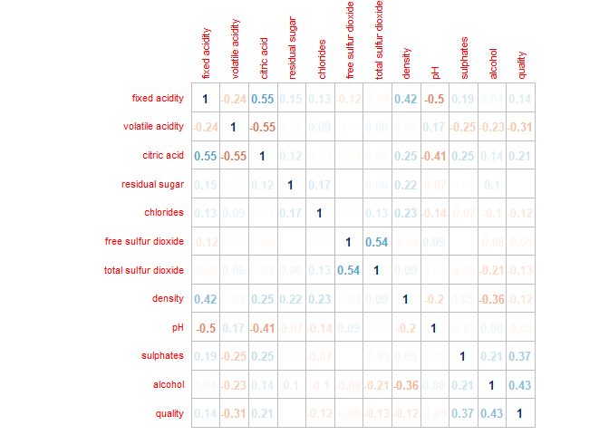

```r
# Matriz de correlaciones
corrplot(corr = cor(x = dataset, method = "pearson"), method = "number",
         tl.cex = 0.7,number.cex = 0.8, cl.pos = "n")
```

Las variables acidez volátil (r = -0.31, p-value = < 2.2e-16), sulfato (r = 0.37, p-value = < 2.2e-16) y alcohol (r = 0.43, p-value = < 2.2e-16) tiene una correlacion media con la variable calidad en comparación con las otras variables del dataset que tienen correlación insignificante.

#### 2.4.3.2 Regresiones

```r
# Regresión lineal simple
summary(lm(quality~`fixed acidity`, data=dataset))
```

```
##
## Call:
## lm(formula = quality ~ `fixed acidity`, data = dataset)
##
## Residuals:
##     Min      1Q  Median      3Q     Max
## -2.9446 -0.6077  0.1556  0.4470  2.4561
##
## Coefficients:
##                 Estimate Std. Error t value Pr(>|t|)
## (Intercept)      4.88820    0.12997  37.611  < 2e-16 ***
## `fixed acidity`  0.09107    0.01564   5.823 6.97e-09 ***
## ---
## Signif. codes:  0 '***' 0.001 '**' 0.01 '*' 0.05 '.' 0.1 ' ' 1
##
## Residual standard error: 0.7994 on 1597 degrees of freedom
## Multiple R-squared:  0.02079,    Adjusted R-squared:  0.02018
## F-statistic: 33.91 on 1 and 1597 DF,  p-value: 6.967e-09
```

```r
summary(lm(quality~`volatile acidity`, data=dataset))
```

```
##
## Call:
## lm(formula = quality ~ `volatile acidity`, data = dataset)
##
## Residuals:
##      Min       1Q   Median       3Q      Max
## -2.78636 -0.56333  0.00919  0.46455  2.54819
##
## Coefficients:
##                    Estimate Std. Error t value Pr(>|t|)
## (Intercept)         6.60416    0.07766   85.04   <2e-16 ***
## `volatile acidity` -1.85861    0.14445  -12.87   <2e-16 ***
## ---
## Signif. codes:  0 '***' 0.001 '**' 0.01 '*' 0.05 '.' 0.1 ' ' 1
##
## Residual standard error: 0.7689 on 1597 degrees of freedom
## Multiple R-squared:  0.09393,    Adjusted R-squared:  0.09336
## F-statistic: 165.6 on 1 and 1597 DF,  p-value: < 2.2e-16
```

```r
summary(lm(quality~`citric acid`, data=dataset))
```

```
##
## Call:
## lm(formula = quality ~ `citric acid`, data = dataset)
##
## Residuals:
##     Min      1Q  Median      3Q     Max
## -2.8690 -0.6160  0.1213  0.4911  2.5787
##
## Coefficients:
##               Estimate Std. Error t value Pr(>|t|)
## (Intercept)    5.39215    0.03505 153.858   <2e-16 ***
## `citric acid`  0.97311    0.11548   8.427   <2e-16 ***
## ---
## Signif. codes:  0 '***' 0.001 '**' 0.01 '*' 0.05 '.' 0.1 ' ' 1
##
## Residual standard error: 0.7904 on 1597 degrees of freedom
## Multiple R-squared:  0.04257,    Adjusted R-squared:  0.04197
## F-statistic: 71.01 on 1 and 1597 DF,  p-value: < 2.2e-16
```

```r
summary(lm(quality~`residual sugar`, data=dataset))
```

```
##
## Call:
## lm(formula = quality ~ `residual sugar`, data = dataset)
##
## Residuals:
##     Min      1Q  Median      3Q     Max
## -2.6465 -0.6353  0.3604  0.3658  2.3674
##
## Coefficients:
##                  Estimate Std. Error t value Pr(>|t|)
## (Intercept)       5.62329    0.08309  67.677   <2e-16 ***
## `residual sugar`  0.00545    0.03450   0.158    0.875
## ---
## Signif. codes:  0 '***' 0.001 '**' 0.01 '*' 0.05 '.' 0.1 ' ' 1
##
## Residual standard error: 0.8078 on 1597 degrees of freedom
## Multiple R-squared:  1.562e-05,  Adjusted R-squared:  -0.0006105
## F-statistic: 0.02495 on 1 and 1597 DF,  p-value: 0.8745
```

```r
summary(lm(quality~chlorides, data=dataset))
```

```
##
## Call:
## lm(formula = quality ~ chlorides, data = dataset)
##
## Residuals:
##     Min      1Q  Median      3Q     Max
## -2.7798 -0.6376  0.2344  0.3979  2.4050
##
## Coefficients:
##             Estimate Std. Error t value Pr(>|t|)
## (Intercept)   6.2134     0.1201  51.740  < 2e-16 ***
## chlorides    -7.1091     1.4578  -4.877 1.19e-06 ***
## ---
## Signif. codes:  0 '***' 0.001 '**' 0.01 '*' 0.05 '.' 0.1 ' ' 1
##
## Residual standard error: 0.8019 on 1597 degrees of freedom
## Multiple R-squared:  0.01467,    Adjusted R-squared:  0.01406
## F-statistic: 23.78 on 1 and 1597 DF,  p-value: 1.186e-06
```

```r
summary(lm(quality~`free sulfur dioxide`, data=dataset))
```

```
##
## Call:
## lm(formula = quality ~ `free sulfur dioxide`, data = dataset)
##
## Residuals:
##     Min      1Q  Median      3Q     Max
## -2.6900 -0.6356  0.3154  0.3807  2.4678
##
## Coefficients:
##                        Estimate Std. Error t value Pr(>|t|)
## (Intercept)            5.717236   0.043176 132.418   <2e-16 ***
## `free sulfur dioxide` -0.005441   0.002558  -2.128   0.0335 *
## ---
## Signif. codes:  0 '***' 0.001 '**' 0.01 '*' 0.05 '.' 0.1 ' ' 1
##
## Residual standard error: 0.8067 on 1597 degrees of freedom
## Multiple R-squared:  0.002826,   Adjusted R-squared:  0.002202
## F-statistic: 4.526 on 1 and 1597 DF,  p-value: 0.03353
```

```r
summary(lm(quality~`total sulfur dioxide`, data=dataset))
```

```
##
## Call:
## lm(formula = quality ~ `total sulfur dioxide`, data = dataset)
##
## Residuals:
##     Min      1Q  Median      3Q     Max
## -2.7712 -0.6451  0.2498  0.3885  2.5524
##
## Coefficients:
##                          Estimate Std. Error t value Pr(>|t|)
## (Intercept)             5.8173985  0.0410734 141.634  < 2e-16 ***
## `total sulfur dioxide` -0.0042021  0.0008306  -5.059  4.7e-07 ***
## ---
## Signif. codes:  0 '***' 0.001 '**' 0.01 '*' 0.05 '.' 0.1 ' ' 1
##
## Residual standard error: 0.8014 on 1597 degrees of freedom
## Multiple R-squared:  0.01577,    Adjusted R-squared:  0.01516
## F-statistic: 25.59 on 1 and 1597 DF,  p-value: 4.7e-07
```

```r
summary(lm(quality~density, data=dataset))
```

```
##
## Call:
## lm(formula = quality ~ density, data = dataset)
##
## Residuals:
##     Min      1Q  Median      3Q     Max
## -2.7869 -0.6332  0.2204  0.4034  2.5133
##
## Coefficients:
##             Estimate Std. Error t value Pr(>|t|)
## (Intercept)    78.61      14.87   5.288 1.41e-07 ***
## density       -73.21      14.91  -4.909 1.01e-06 ***
## ---
## Signif. codes:  0 '***' 0.001 '**' 0.01 '*' 0.05 '.' 0.1 ' ' 1
##
## Residual standard error: 0.8018 on 1597 degrees of freedom
## Multiple R-squared:  0.01486,    Adjusted R-squared:  0.01425
## F-statistic:  24.1 on 1 and 1597 DF,  p-value: 1.01e-06
```

```r
summary(lm(quality~pH, data=dataset))
```

```
##
## Call:
## lm(formula = quality ~ pH, data = dataset)
##
## Residuals:
##     Min      1Q  Median      3Q     Max
## -2.6928 -0.6359  0.3034  0.3906  2.4588
##
## Coefficients:
##             Estimate Std. Error t value Pr(>|t|)
## (Intercept)   6.8901     0.5881  11.716   <2e-16 ***
## pH           -0.3789     0.1776  -2.134    0.033 *
## ---
## Signif. codes:  0 '***' 0.001 '**' 0.01 '*' 0.05 '.' 0.1 ' ' 1
##
## Residual standard error: 0.8067 on 1597 degrees of freedom
## Multiple R-squared:  0.002843,   Adjusted R-squared:  0.002218
## F-statistic: 4.553 on 1 and 1597 DF,  p-value: 0.03301
```

```r
summary(lm(quality~sulphates, data=dataset))
```

```
##
## Call:
## lm(formula = quality ~ sulphates, data = dataset)
##
## Residuals:
##     Min      1Q  Median      3Q     Max
## -3.2536 -0.5165 -0.1402  0.5118  2.3984
##
## Coefficients:
##             Estimate Std. Error t value Pr(>|t|)
## (Intercept)   3.8156     0.1174   32.50   <2e-16 ***
## sulphates     2.8348     0.1805   15.71   <2e-16 ***
## ---
## Signif. codes:  0 '***' 0.001 '**' 0.01 '*' 0.05 '.' 0.1 ' ' 1
##
## Residual standard error: 0.7518 on 1597 degrees of freedom
## Multiple R-squared:  0.1338, Adjusted R-squared:  0.1333
## F-statistic: 246.8 on 1 and 1597 DF,  p-value: < 2.2e-16
```

```r
summary(lm(quality~alcohol, data=dataset))
```

```
##
## Call:
## lm(formula = quality ~ alcohol, data = dataset)
##
## Residuals:
##     Min      1Q  Median      3Q     Max
## -2.8970 -0.4114 -0.1687  0.5076  2.5886
##
## Coefficients:
##             Estimate Std. Error t value Pr(>|t|)
## (Intercept)   1.4462     0.2213   6.535 8.52e-11 ***
## alcohol       0.4046     0.0213  18.999  < 2e-16 ***
## ---
## Signif. codes:  0 '***' 0.001 '**' 0.01 '*' 0.05 '.' 0.1 ' ' 1
##
## Residual standard error: 0.7296 on 1597 degrees of freedom
## Multiple R-squared:  0.1844, Adjusted R-squared:  0.1838
## F-statistic:   361 on 1 and 1597 DF,  p-value: < 2.2e-16
```

```r
# Regresión lineal multiple
summary(lm(quality~., data=dataset))
```

```
##
## Call:
## lm(formula = quality ~ ., data = dataset)
##
## Residuals:
##      Min       1Q   Median       3Q      Max
## -2.98611 -0.40669 -0.05267  0.47672  2.25781
##
## Coefficients:
##                          Estimate Std. Error t value Pr(>|t|)
## (Intercept)            11.0232936 16.1387724   0.683  0.49469
## `fixed acidity`         0.0340986  0.0184821   1.845  0.06523 .
## `volatile acidity`     -0.9298048  0.1594208  -5.832 6.61e-09 ***
## `citric acid`          -0.1058653  0.1440476  -0.735  0.46249
## `residual sugar`       -0.0344828  0.0307736  -1.121  0.26266
## chlorides              -3.4555102  1.3022681  -2.653  0.00805 **
## `free sulfur dioxide`  -0.0009216  0.0025970  -0.355  0.72273
## `total sulfur dioxide` -0.0006031  0.0008667  -0.696  0.48659
## density                -8.3534638 16.2346440  -0.515  0.60694
## pH                     -0.2787527  0.1808418  -1.541  0.12341
## sulphates               1.9298055  0.1740871  11.085  < 2e-16 ***
## alcohol                 0.3142783  0.0238023  13.204  < 2e-16 ***
## ---
## Signif. codes:  0 '***' 0.001 '**' 0.01 '*' 0.05 '.' 0.1 ' ' 1
##
## Residual standard error: 0.679 on 1587 degrees of freedom
## Multiple R-squared:  0.298,  Adjusted R-squared:  0.2931
## F-statistic: 61.25 on 11 and 1587 DF,  p-value: < 2.2e-16
```

#### 2.4.3.3 Random forest y tree decision

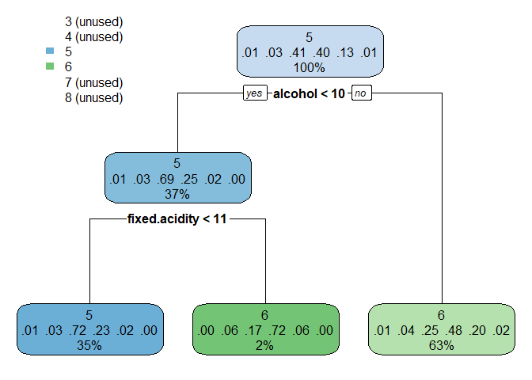

```r
# Conversión de la variable quality a tipo factor
dataset$quality<-factor(dataset$quality)

# División de los datos en train y test
set.seed(123)
train <- sample(1:nrow(dataset), round(nrow(dataset)*0.7), replace = FALSE)
dataset_train <- dataset[train,]
dataset_test  <- dataset[-train,]

# Entrenamiento del modelo tree decision
set.seed(123)
names(dataset_train)<-make.names(names(dataset_train))
modelo <- rpart(quality ~ ., data = dataset_train)
rpart.plot(modelo)
```

```r
# Hacer predicciones del modelos
names(dataset_test)<-make.names(names(dataset_test))
prediccion <- predict(modelo, dataset_test, type = "class")

# Matriz de confusión
confusionMatrix(prediccion, dataset_test$quality)
```

```
## Confusion Matrix and Statistics
##
##           Reference
## Prediction   3   4   5   6   7   8
##          3   0   0   0   0   0   0
##          4   0   0   0   0   0   0
##          5   1   7 128  63   3   0
##          6   2   7  89 132  45   3
##          7   0   0   0   0   0   0
##          8   0   0   0   0   0   0
##
## Overall Statistics
##
##                Accuracy : 0.5417
##                  95% CI : (0.4959, 0.5869)
##     No Information Rate : 0.4521
##     P-Value [Acc > NIR] : 5.084e-05
##
##                   Kappa : 0.2022
##
##  Mcnemar's Test P-Value : NA
##
## Statistics by Class:
##
##                      Class: 3 Class: 4 Class: 5 Class: 6 Class: 7 Class: 8
## Sensitivity           0.00000  0.00000   0.5899   0.6769      0.0  0.00000
## Specificity           1.00000  1.00000   0.7186   0.4877      1.0  1.00000
## Pos Pred Value            NaN      NaN   0.6337   0.4748      NaN      NaN
## Neg Pred Value        0.99375  0.97083   0.6799   0.6881      0.9  0.99375
## Prevalence            0.00625  0.02917   0.4521   0.4062      0.1  0.00625
## Detection Rate        0.00000  0.00000   0.2667   0.2750      0.0  0.00000
## Detection Prevalence  0.00000  0.00000   0.4208   0.5792      0.0  0.00000
## Balanced Accuracy     0.50000  0.50000   0.6542   0.5823      0.5  0.50000
```

```r
# Entrenamiento del modelo random forest
set.seed(123)
modelo1 <- randomForest(quality ~ ., data = dataset_train)
modelo1$importance
```

```
##                      MeanDecreaseGini
## fixed.acidity                57.88032
## volatile.acidity             67.66015
## citric.acid                  56.32242
## residual.sugar               47.56480
## chlorides                    64.43770
## free.sulfur.dioxide          53.39309
## total.sulfur.dioxide         69.63897
## density                      62.22508
## pH                           56.31074
## sulphates                    80.27574
## alcohol                     112.64744
```

```r
# Hacer predicciones del modelos
names(dataset_test)<-make.names(names(dataset_test))
predicciones <- predict(modelo1, dataset_test)

# Matriz de confusión
confusionMatrix(predicciones, dataset_test$quality)
```

```
## Confusion Matrix and Statistics
##
##           Reference
## Prediction   3   4   5   6   7   8
##          3   0   0   0   0   0   0
##          4   0   0   0   0   0   0
##          5   1   8 159  47   0   0
##          6   2   6  58 143  29   2
##          7   0   0   0   5  19   0
##          8   0   0   0   0   0   1
##
## Overall Statistics
##
##                Accuracy : 0.6708
##                  95% CI : (0.6268, 0.7127)
##     No Information Rate : 0.4521
##     P-Value [Acc > NIR] : < 2.2e-16
##
##                   Kappa : 0.4415
##
##  Mcnemar's Test P-Value : NA
##
## Statistics by Class:
##
##                      Class: 3 Class: 4 Class: 5 Class: 6 Class: 7 Class: 8
## Sensitivity           0.00000  0.00000   0.7327   0.7333  0.39583 0.333333
## Specificity           1.00000  1.00000   0.7871   0.6596  0.98843 1.000000
## Pos Pred Value            NaN      NaN   0.7395   0.5958  0.79167 1.000000
## Neg Pred Value        0.99375  0.97083   0.7811   0.7833  0.93640 0.995825
## Prevalence            0.00625  0.02917   0.4521   0.4062  0.10000 0.006250
## Detection Rate        0.00000  0.00000   0.3312   0.2979  0.03958 0.002083
## Detection Prevalence  0.00000  0.00000   0.4479   0.5000  0.05000 0.002083
## Balanced Accuracy     0.50000  0.50000   0.7599   0.6965  0.69213 0.666667
```

## 2.5 Representación de los resultados a partir de tablas y gráficas.

[output not shown]

# 3 Recursos

- Calvo M, Subirats L, Pérez D (2019). Introducción a la limpieza y análisis de los datos. Editorial UOC.
- Tutorial de Github (https://guides.github.com/activities/hello-world/)
- Squire, Megan (2015). Clean Data. Packt Publishing Ltd.
- Jiawei Han, Micheine Kamber, Jian Pei (2012). Data mining: concepts and techniques. Morgan Kaufmann.
- Jason W. Osborne (2010). Data Cleaning Basics: Best Practices in Dealing with Extreme Scores. Newborn and Infant Nursing Reviews; 10 (1): pp. 1527-3369.
- Peter Dalgaard (2008). Introductory statistics with R. Springer Science & Business Media.
- Wes McKinney (2012). Python for Data Analysis. O’Reilley Media, Inc.